# logrxpackage

# Generating a log

The purpose of the `logrx` package is to generate a log upon execution of an R script which enables traceability and reproducibility of the executed code. Generating a log with `{logrx}` can be as simple as running one line of code as seen in the below example of how to use the `axecute()` function.. However, `{logrx}` has much more advanced capabilities to meet the demands of Clinical Reporting. To learn additional techniques about executing code with `{logrx}` please visit our [Execution Vignette](https://pharmaverse.github.io/logrx/articles/execution.html).

## `axecute()`

`axecute()` enables the command line submission of a program. A log is set-up around the program, and its code is run safely and loudly (using `safely()` from the `purrr` package). The log will be generated in the same folder as the script unless you specify differently.

```r
axecute("my_script.R")
```

## `logrx` addin:

A log can be generated using the `{logrx}` addin, which is a simple point and click interface that allows you to run a single program. The Addin ships with the package and is available once you use install the package. The gif on the [Get Started](https://pharmaverse.github.io/logrx/index.html) page gives a quick snapshot of its intended use.

# Log attributes

We have compiled a brief overview of the information that we capture in the log file generated by `{logrx}`. We allow users to customize sections of the log based on their needs for a log, e.g. you can toggle on/off the messages, outputs, errors and messages. You can also build into your log approved and unapproved packages used in your R script - see [Logging Unapproved Package and Function Use](https://pharmaverse.github.io/logrx/articles/approved.html) for additional guidance

The following attributes are recorded in the log:

- **Metadata**: `{logrx}` package information
  - Version of the package
  - Type of build
  - Link to the GitHub repository
- **User and File Information**
  - User that generated the log
  - Name and path of the script for which the log was generated
  - `hash_sum`: A unique hashsum is created for the log file
- **Session Information**: The R session information
  - R version
  - OS and system
  - GUI
  - Language and timezone
  - Packages - List of all available packages in the environment
  - External Software - List of all external software
- **Masked Functions** - List of all functions masked by packages
- **Program Run Time Information** - Start, end, and run times
- **Used Package and Functions (optional)** - List of all packages and functions used in the script for which the log was generated
- **Unapproved Package and Functions (optional)** - List of all packages and functions used in the script for which the log was generated that are not part of the approved list of packages and functions
- **Errors and Warnings** - List of Errors and Warnings from the Script
- **Messages, Output and Results (optional)** - List Messages, Outputs and Results
- **Log Output File** - Name and path of the log

Below we have a scrollable example of what is included in a log file for an `adsl.R` script.

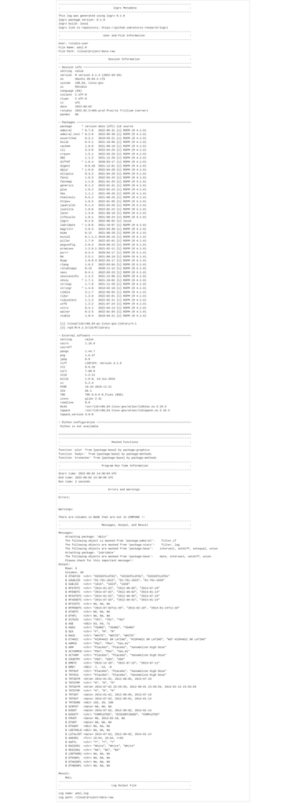